# Pitcher WAR

Sanjay Pothula

August 21, 2019

## How is Fangraphs Pitching WAR calculated?

fWAR for pitchers is FIP-based (Fielding Independent Pitching), meaning that incorporates indicators that play an importance into ERA over a large sample of ERA.

The main problem that I see with using FIP, the derivation of runs is not the same as batters.

An appropriate way to calculate the run value for batters is to utilize the linear weights for a 1B, 2B, 3B, HR, SO, BB, and HBP above the out average. With these linear weights, it is pretty easy to calculate a wRAA (weighted Runs Above Average), a key component for WAR.

$$wRAA \ for \ Batters = (wOBA - LGwOBA)*PA$$
However, for FIP, this calculation is not the same at all. If you would like to look at the gory details, I have included the link to how to calculate it (https://library.fangraphs.com/calculating-pitcher-war-a-complete-example/). In any case, the primary question that I would ask is how can we value pitchers and batters on the same scale if their methodology to getting to WAR is entirely different.

## How could we alleviate Pitching WAR?

I would propose using wOBA for pitching WAR. This would translate to a wRAA measurement that would allow for pitchers and batters to be appropriately comparable.

## How do we improve Pitching WAR?

A big problem with FIP is that it is useful in a big sample of innings pitched, composing of strikeouts, walks, and home runs allowed. These three outcomes take a long to normalize for a single pitcher, especially for innings pitched. wOBA will run into this problem as well because, like K/9, BB/9, and HR/9, the outcomes of wOBA (1B, 2B, 3B, HR, SO, BB, and HBP) take a long time to normalize at the per-PA level.

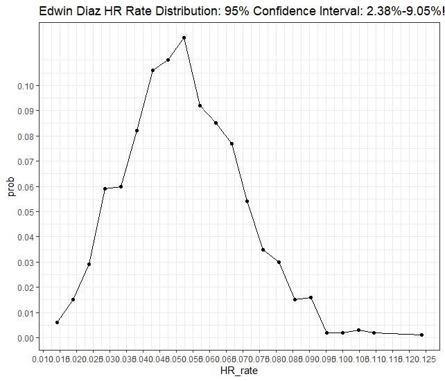

If we want to solve this problem, we have to normalize the components at the batted ball and per-pitch level, which will normalize much faster because there are obviously more batted balls than batted ball events (1B, 2B, 3B, HR) and more pitches than strikeouts/walks. This involves predicting these events with batted balls and pitches through models.

## wOBA-based WAR

|  | Name | Age | Team | G | GS | IP | wOBA | wOBAadj | wRAA | replacementLevel | WAR |
| --- | --- | --- | --- | --- | --- | --- | --- | --- | --- | --- | --- |
| 1 | Justin Verlander | 36 | Houston | 26 | 26 | 169.2 | 0.219 | 0.219 | 39.18 | 17.3 | 6.1 |
| 2 | Shane Bieber | 24 | Cleveland | 27 | 26 | 168.1 | 0.236 | 0.236 | 28.77 | 17.72 | 5 |
| 3 | German Marquez | 24 | Colorado | 27 | 27 | 168 | 0.268 | 0.278 | 0.7 | 18.25 | 2 |
| 4 | Lance Lynn | 32 | Texas | 26 | 26 | 165 | 0.253 | 0.253 | 17.91 | 18.25 | 3.9 |
| 5 | Stephen Strasburg | 30 | Washington | 26 | 26 | 165 | 0.235 | 0.245 | 22.79 | 17.75 | 4.4 |
| 6 | Madison Bumgarner | 29 | San Francisco | 27 | 27 | 164.2 | 0.252 | 0.262 | 11.23 | 17.48 | 3.1 |
| 7 | Brad Keller | 23 | Kansas City | 27 | 27 | 164 | 0.263 | 0.263 | 11.17 | 18.49 | 3.2 |
| 8 | Mike Minor | 31 | Texas | 25 | 25 | 162 | 0.252 | 0.252 | 17.74 | 17.4 | 3.8 |
| 9 | Aaron Nola | 26 | Philadelphia | 27 | 27 | 161.1 | 0.257 | 0.267 | 8.11 | 17.88 | 2.8 |
| 10 | Jose Berrios | 25 | Minnesota | 25 | 25 | 157.2 | 0.255 | 0.255 | 15.82 | 17.45 | 3.6 |

[output cut: 724 more lines]

## Fangraphs FIP-based WAR

|  | Name | Team | G | GS | IP | FIP | WAR |
| --- | --- | --- | --- | --- | --- | --- | --- |
| 1 | Hyun-Jin Ryu | Dodgers | 23 | 23 | 148.1 | 2.99 | 4.1 |
| 2 | Mike Soroka | Braves | 22 | 22 | 134.2 | 3.29 | 3.4 |
| 3 | Max Scherzer | Nationals | 20 | 20 | 134.1 | 2.08 | 5.7 |
| 4 | Jacob deGrom | Mets | 25 | 25 | 155 | 2.8 | 5.1 |
| 5 | Clayton Kershaw | Dodgers | 22 | 22 | 143 | 3.46 | 3.4 |
| 6 | Charlie Morton | Rays | 26 | 26 | 156 | 2.67 | 5.2 |
| 7 | Justin Verlander | Astros | 26 | 26 | 169.2 | 3.59 | 4.2 |
| 8 | Zack Greinke | - - - | 26 | 26 | 165 | 3.33 | 4.1 |
| 9 | Gerrit Cole | Astros | 25 | 25 | 156.2 | 3.1 | 4.5 |
| 10 | Sonny Gray | Reds | 25 | 25 | 138.2 | 3.39 | 3.6 |

[output cut: 58 more lines]